# Anexo

Vamos a probar distintas combianciones de variables para ver con cuál de ellas obtenemos mejores resultados. La única variable que vamos a dejar siempre fuera, a excepción de la primera prueba, es 'device_fraud_count' porque vimos en el EDA que era constante. El resto de variables que vamos a eliminar a lo largo de las pruebas, son aquellas que eliminamos en el notebook de la selección de variables, siendo las combinaciones que realicemos aleatorias.

## Librerías

```python
import pandas as pd
import matplotlib.pyplot as plt
from sklearn.preprocessing import StandardScaler
from sklearn.model_selection import train_test_split, RandomizedSearchCV
from sklearn.pipeline import Pipeline
from sklearn.metrics import classification_report, confusion_matrix, make_scorer, fbeta_score, ConfusionMatrixDisplay
from imblearn.under_sampling import RandomUnderSampler
from lightgbm import LGBMClassifier
import time
```

```python
def procesar_datos_y_modelo(train, test, columnas_eliminar):
    '''
    ----------------------------------------------------------------------------------------------------------
    Function procesar_datos_y_modelo:
    ----------------------------------------------------------------------------------------------------------
        -Description: Function that performs the processing of train and test, and performs the search for
        hyperparameters using RandomizedSearchCV
        -Inputs:
            -- train: Pandas dataframe containing training data
            -- test: Pandas dataframe containing test data
            -- columnas_eliminar: list with the name of the columns that you want to eliminate
        -Return:
            -- best_params: Best values of the hyperparameters obtained by the CV
            -- train: Pandas dataframe with the training data already processed
            -- test: Pandas dataframe with the test data already processed
    '''

    # Target Variable split
    X_train = train.drop('fraud_bool', axis=1)
    y_train = train['fraud_bool']
    X_test = test.drop('fraud_bool', axis=1)
    y_test = test['fraud_bool']

    # New variable
    X_train['ratio_inc_cred'] = X_train['income'] / X_train['proposed_credit_limit']
    X_test['ratio_inc_cred'] = X_test['income'] / X_test['proposed_credit_limit']

    # Variable's drop
    X_train = X_train.drop(columns=columnas_eliminar)
    X_test = X_test.drop(columns=columnas_eliminar)

    # Coding categorical variables
    X_train_dummy = pd.DataFrame(pd.get_dummies(X_train, drop_first=True))
    X_test_dummy = pd.DataFrame(pd.get_dummies(X_test, drop_first=True))

    # Estandarization
    scaler = StandardScaler()
    X_train_scaled = pd.DataFrame(scaler.fit_transform(X_train_dummy), columns=X_train_dummy.columns, index=X_train_dummy.index)
    X_test_scaled = pd.DataFrame(scaler.fit_transform(X_test_dummy), columns=X_test_dummy.columns, index=X_test_dummy.index)


    # Data balancing
    random_under = RandomUnderSampler(random_state=33, sampling_strategy=0.2)
    X_train_balanced, y_train_balanced = random_under.fit_resample(X_train_scaled, y_train)

    # Set up scoring function
    f2_score = make_scorer(fbeta_score, beta=2)

    # We define the hyperparameter search space
    espacio_hiperparametros = {
        'learning_rate': [0.1, 0.2, 0.3, 0.4, 0.5],
        'n_estimators': [300, 350, 400, 450, 500, 550, 600],
        'num_leaves': [3, 5, 7, 10, 12, 20, 40],
        'max_depth': [3, 7, 12, 16, 20, 25],
        'subsample': [0.8, 0.9, 1.0],
        'colsample_bytree': [0.8, 0.9, 1.0],
        'min_child_samples': [3, 5, 7, 10, 20, 30]
    }

    # We set up the search
    random_search = RandomizedSearchCV(estimator=LGBMClassifier(objective='binary', random_state=33, verbose=-1),
                                param_distributions=espacio_hiperparametros,
                                n_iter=100,
                                scoring=f2_score,
                                cv=5,
                                verbose=2,
                                random_state=33,
                                n_jobs=-1)

    random_search.fit(X_train_balanced, y_train_balanced)

    best_params = random_search.best_params_
    print("Mejores hiperparámetros:", best_params)

    # Metrics
    light_gbm = LGBMClassifier(**best_params, verbose=-1)

    light_gbm.fit(X_train_balanced, y_train_balanced)
    y_pred_light_gbm = light_gbm.predict(X_test_scaled)

    classification_report_light_gbm = classification_report(y_test, y_pred_light_gbm)
    f2_light_gbm = fbeta_score(y_test, y_pred_light_gbm, beta=2)
    matriz_confusion_light_gbm = confusion_matrix(y_test, y_pred_light_gbm)

    print("Light GBM")
    print("Classification Report:", "\n", classification_report_light_gbm)
    print("F2 score: %.3f" % f2_light_gbm)
    disp = ConfusionMatrixDisplay(confusion_matrix=matriz_confusion_light_gbm)
    disp.plot()
    plt.xlabel("Predicción")
    plt.ylabel("Valores Reales")
    plt.title("Matriz de confusión")
    plt.show()

    train = pd.concat((X_train_balanced, y_train_balanced),axis=1)
    test = pd.concat((X_test_scaled, y_test),axis=1)
    return best_params, train, test
```

```python
pd_fraude_train = pd.read_csv('./data/train_fraude_eda.csv')
pd_fraude_test = pd.read_csv('./data/test_fraude_eda.csv')

pd_fraude_train = pd_fraude_train.drop('Unnamed: 0', axis=1)
pd_fraude_test = pd_fraude_test.drop('Unnamed: 0', axis=1)

pd_fraude_train.columns
```

```
Index(['income', 'name_email_similarity', 'prev_address_months_count',
       'current_address_months_count', 'customer_age', 'days_since_request',
       'intended_balcon_amount', 'payment_type', 'zip_count_4w', 'velocity_6h',
       'velocity_24h', 'velocity_4w', 'bank_branch_count_8w',
       'date_of_birth_distinct_emails_4w', 'employment_status',
       'credit_risk_score', 'email_is_free', 'housing_status',
       'phone_home_valid', 'phone_mobile_valid', 'bank_months_count',
       'has_other_cards', 'proposed_credit_limit', 'foreign_request', 'source',
       'session_length_in_minutes', 'device_os', 'keep_alive_session',
       'device_distinct_emails_8w', 'device_fraud_count', 'month',
       'fraud_bool'],
      dtype='object')
```

```python
print(pd_fraude_train.shape, pd_fraude_test.shape)
```

```
(800000, 32) (200000, 32)
```

## Combinaciones de variables y búsqueda de hiperparámetros

```
Fitting 5 folds for each of 100 candidates, totalling 500 fits
Mejores hiperparámetros: {'subsample': 0.9, 'num_leaves': 20, 'n_estimators': 300, 'min_child_samples': 5, 'max_depth': 3, 'learning_rate': 0.4, 'colsample_bytree': 0.9}
Light GBM
Classification Report:
               precision    recall  f1-score   support

           0       0.99      0.95      0.97    197794
           1       0.11      0.50      0.17      2206

    accuracy                           0.95    200000
   macro avg       0.55      0.73      0.57    200000
weighted avg       0.98      0.95      0.96    200000

F2 score: 0.287
```

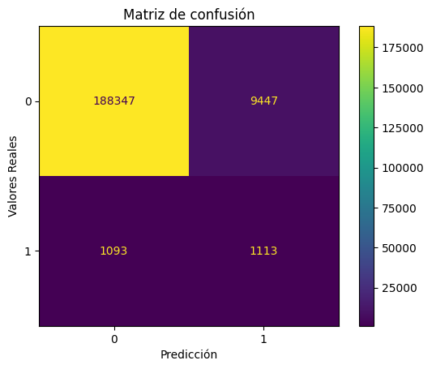

```
CPU times: total: 52.6 s
Wall time: 4min
```

```python
%%time

columnas_eliminar_0 = [
    'income',
    'proposed_credit_limit'
]

hiperparametros_0, train_0, test_0 = procesar_datos_y_modelo(pd_fraude_train, pd_fraude_test, columnas_eliminar_0)
```

```
Fitting 5 folds for each of 100 candidates, totalling 500 fits
Mejores hiperparámetros: {'subsample': 0.8, 'num_leaves': 3, 'n_estimators': 500, 'min_child_samples': 30, 'max_depth': 7, 'learning_rate': 0.5, 'colsample_bytree': 1.0}
Light GBM
Classification Report:
               precision    recall  f1-score   support

           0       0.99      0.96      0.98    197794
           1       0.11      0.47      0.18      2206

    accuracy                           0.95    200000
   macro avg       0.55      0.71      0.58    200000
weighted avg       0.98      0.95      0.97    200000

F2 score: 0.282
```

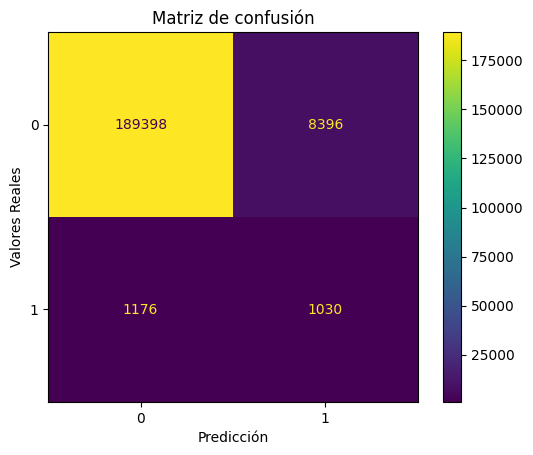

```
CPU times: total: 37 s
Wall time: 3min 20s
```

```python
%%time

columnas_eliminar_1 = [
    'phone_mobile_valid',
    'source',
    'keep_alive_session',
    'device_fraud_count',
    'email_is_free',
    'has_other_cards',
    'velocity_6h',
    'velocity_24h',
    'velocity_4w',
    'income',
    'proposed_credit_limit'
]

hiperparametros_1, train_1, test_1 = procesar_datos_y_modelo(pd_fraude_train, pd_fraude_test, columnas_eliminar_1)
```

```
Fitting 5 folds for each of 100 candidates, totalling 500 fits
Mejores hiperparámetros: {'subsample': 0.9, 'num_leaves': 20, 'n_estimators': 300, 'min_child_samples': 5, 'max_depth': 3, 'learning_rate': 0.4, 'colsample_bytree': 0.9}
Light GBM
Classification Report:
               precision    recall  f1-score   support

           0       0.99      0.95      0.97    197794
           1       0.11      0.50      0.17      2206

    accuracy                           0.95    200000
   macro avg       0.55      0.73      0.57    200000
weighted avg       0.98      0.95      0.96    200000

F2 score: 0.287
```

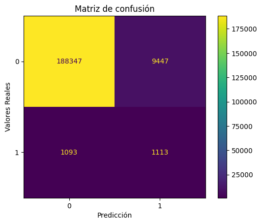

```
CPU times: total: 52.2 s
Wall time: 3min 39s
```

```python
%%time

columnas_eliminar_2 = [
    'device_fraud_count',
    'income',
    'proposed_credit_limit'
]

hiperparametros_2, train_2, test_2 = procesar_datos_y_modelo(pd_fraude_train, pd_fraude_test, columnas_eliminar_2)
```

```
Fitting 5 folds for each of 100 candidates, totalling 500 fits
Mejores hiperparámetros: {'subsample': 1.0, 'num_leaves': 3, 'n_estimators': 600, 'min_child_samples': 7, 'max_depth': 20, 'learning_rate': 0.4, 'colsample_bytree': 0.9}
Light GBM
Classification Report:
               precision    recall  f1-score   support

           0       0.99      0.96      0.98    197794
           1       0.12      0.49      0.19      2206

    accuracy                           0.95    200000
   macro avg       0.55      0.72      0.58    200000
weighted avg       0.98      0.95      0.97    200000

F2 score: 0.297
```

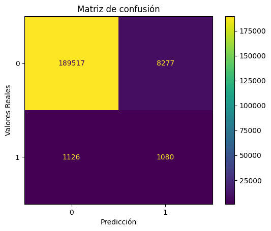

```
CPU times: total: 47 s
Wall time: 3min 39s
```

```python
%%time

columnas_eliminar_3 = [
    'device_fraud_count',
    'phone_mobile_valid',
    'has_other_cards',
    'income',
    'proposed_credit_limit'
]

hiperparametros_3, train_3, test_3 = procesar_datos_y_modelo(pd_fraude_train, pd_fraude_test, columnas_eliminar_3)
```

```
Fitting 5 folds for each of 100 candidates, totalling 500 fits
Mejores hiperparámetros: {'subsample': 0.8, 'num_leaves': 3, 'n_estimators': 500, 'min_child_samples': 30, 'max_depth': 7, 'learning_rate': 0.5, 'colsample_bytree': 1.0}
Light GBM
Classification Report:
               precision    recall  f1-score   support

           0       0.99      0.96      0.98    197794
           1       0.12      0.51      0.19      2206

    accuracy                           0.95    200000
   macro avg       0.56      0.73      0.58    200000
weighted avg       0.98      0.95      0.97    200000

F2 score: 0.303
```

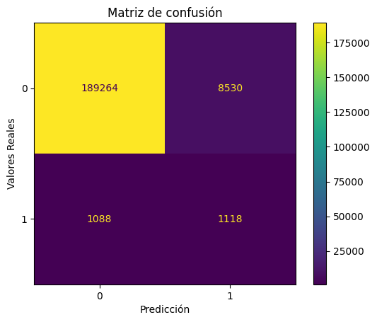

```
CPU times: total: 43.6 s
Wall time: 3min 42s
```

```python
%%time

columnas_eliminar_4 = [
    'device_fraud_count',
    'phone_mobile_valid',
    'velocity_6h',
    'source',
    'income',
    'proposed_credit_limit'
]

hiperparametros_4, train_4, test_4 = procesar_datos_y_modelo(pd_fraude_train, pd_fraude_test, columnas_eliminar_4)
```

```
Fitting 5 folds for each of 100 candidates, totalling 500 fits
Mejores hiperparámetros: {'subsample': 0.9, 'num_leaves': 40, 'n_estimators': 600, 'min_child_samples': 20, 'max_depth': 3, 'learning_rate': 0.3, 'colsample_bytree': 1.0}
Light GBM
Classification Report:
               precision    recall  f1-score   support

           0       0.99      0.95      0.97    197794
           1       0.11      0.52      0.18      2206

    accuracy                           0.95    200000
   macro avg       0.55      0.73      0.58    200000
weighted avg       0.98      0.95      0.96    200000

F2 score: 0.295
```

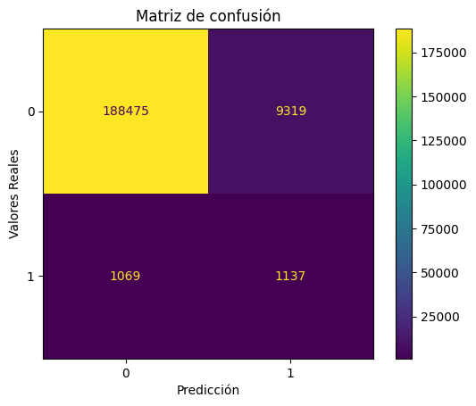

```
CPU times: total: 49 s
Wall time: 3min 25s
```

```python
%%time

columnas_eliminar_5 = [
    'device_fraud_count',
    'phone_mobile_valid',
    'velocity_6h',
    'velocity_24h',
    'income',
    'proposed_credit_limit'
]

hiperparametros_5, train_5, test_5 = procesar_datos_y_modelo(pd_fraude_train, pd_fraude_test, columnas_eliminar_5)
```

```
Fitting 5 folds for each of 100 candidates, totalling 500 fits
Mejores hiperparámetros: {'subsample': 0.8, 'num_leaves': 3, 'n_estimators': 500, 'min_child_samples': 30, 'max_depth': 7, 'learning_rate': 0.5, 'colsample_bytree': 1.0}
Light GBM
Classification Report:
               precision    recall  f1-score   support

           0       0.99      0.96      0.97    197794
           1       0.11      0.47      0.17      2206

    accuracy                           0.95    200000
   macro avg       0.55      0.71      0.57    200000
weighted avg       0.98      0.95      0.97    200000

F2 score: 0.279
```

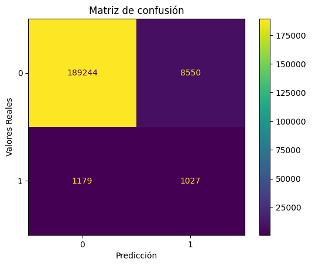

```
CPU times: total: 44.7 s
Wall time: 3min 38s
```

```python
%%time

columnas_eliminar_6 = [
    'device_fraud_count',
    'keep_alive_session',
    'email_is_free',
    'has_other_cards',
    'income',
    'proposed_credit_limit'
]

hiperparametros_6, train_6, test_6 = procesar_datos_y_modelo(pd_fraude_train, pd_fraude_test, columnas_eliminar_6)
```

```
Fitting 5 folds for each of 100 candidates, totalling 500 fits
Mejores hiperparámetros: {'subsample': 1.0, 'num_leaves': 40, 'n_estimators': 300, 'min_child_samples': 20, 'max_depth': 3, 'learning_rate': 0.4, 'colsample_bytree': 0.8}
Light GBM
Classification Report:
               precision    recall  f1-score   support

           0       0.99      0.95      0.97    197794
           1       0.11      0.51      0.18      2206

    accuracy                           0.95    200000
   macro avg       0.55      0.73      0.57    200000
weighted avg       0.98      0.95      0.96    200000

F2 score: 0.292
```

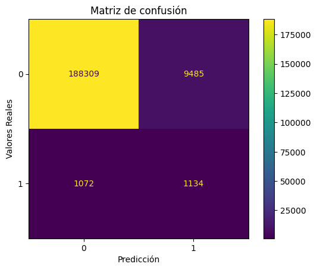

```
CPU times: total: 44 s
Wall time: 3min 30s
```

```python
%%time

columnas_eliminar_7 = [
    'device_fraud_count',
    'source',
    'velocity_24h',
    'email_is_free',
    'income',
    'proposed_credit_limit'
]

hiperparametros_7, train_7, test_7 = procesar_datos_y_modelo(pd_fraude_train, pd_fraude_test, columnas_eliminar_7)
```

```
Fitting 5 folds for each of 100 candidates, totalling 500 fits
Mejores hiperparámetros: {'subsample': 1.0, 'num_leaves': 3, 'n_estimators': 600, 'min_child_samples': 7, 'max_depth': 20, 'learning_rate': 0.4, 'colsample_bytree': 0.9}
Light GBM
Classification Report:
               precision    recall  f1-score   support

           0       0.99      0.96      0.98    197794
           1       0.12      0.50      0.19      2206

    accuracy                           0.95    200000
   macro avg       0.56      0.73      0.58    200000
weighted avg       0.98      0.95      0.97    200000

F2 score: 0.301
```

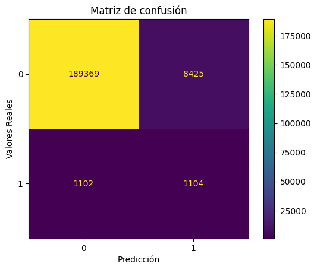

```
CPU times: total: 44.8 s
Wall time: 3min 43s
```

```python
%%time

columnas_eliminar_8 = [
    'device_fraud_count',
    'keep_alive_session',
    'source',
    'income',
    'proposed_credit_limit'
]

hiperparametros_8, train_8, test_8 = procesar_datos_y_modelo(pd_fraude_train, pd_fraude_test, columnas_eliminar_8)
```

```
Fitting 5 folds for each of 100 candidates, totalling 500 fits
Mejores hiperparámetros: {'subsample': 0.8, 'num_leaves': 3, 'n_estimators': 500, 'min_child_samples': 30, 'max_depth': 7, 'learning_rate': 0.5, 'colsample_bytree': 1.0}
Light GBM
Classification Report:
               precision    recall  f1-score   support

           0       0.99      0.96      0.98    197794
           1       0.11      0.49      0.18      2206

    accuracy                           0.95    200000
   macro avg       0.55      0.72      0.58    200000
weighted avg       0.98      0.95      0.97    200000

F2 score: 0.295
```

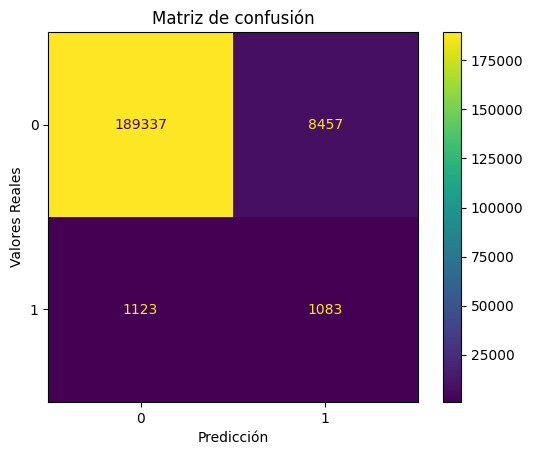

```
CPU times: total: 44.4 s
Wall time: 3min 55s
```

```python
%%time

columnas_eliminar_9 = [
    'device_fraud_count',
    'has_other_cards',
    'velocity_4w',
    'income',
    'proposed_credit_limit'
]

hiperparametros_9, train_9, test_9 = procesar_datos_y_modelo(pd_fraude_train, pd_fraude_test, columnas_eliminar_9)
```

```
Fitting 5 folds for each of 100 candidates, totalling 500 fits
Mejores hiperparámetros: {'subsample': 0.8, 'num_leaves': 3, 'n_estimators': 500, 'min_child_samples': 30, 'max_depth': 7, 'learning_rate': 0.5, 'colsample_bytree': 1.0}
Light GBM
Classification Report:
               precision    recall  f1-score   support

           0       0.99      0.96      0.98    197794
           1       0.12      0.51      0.19      2206

    accuracy                           0.95    200000
   macro avg       0.55      0.73      0.58    200000
weighted avg       0.98      0.95      0.97    200000

F2 score: 0.302
```

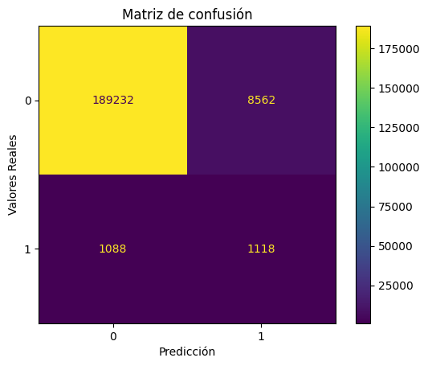

```
CPU times: total: 45.9 s
Wall time: 3min 33s
```

```python
%%time

columnas_eliminar_10 = [
    'device_fraud_count',
    'email_is_free',
    'velocity_4w',
    'income',
    'proposed_credit_limit'
]

hiperparametros_10, train_10, test_10 = procesar_datos_y_modelo(pd_fraude_train, pd_fraude_test, columnas_eliminar_10)
```

```
Fitting 5 folds for each of 100 candidates, totalling 500 fits
Mejores hiperparámetros: {'subsample': 0.8, 'num_leaves': 12, 'n_estimators': 600, 'min_child_samples': 20, 'max_depth': 3, 'learning_rate': 0.2, 'colsample_bytree': 0.9}
Light GBM
Classification Report:
               precision    recall  f1-score   support

           0       0.99      0.96      0.97    197794
           1       0.11      0.50      0.18      2206

    accuracy                           0.95    200000
   macro avg       0.55      0.73      0.58    200000
weighted avg       0.98      0.95      0.97    200000

F2 score: 0.296
```

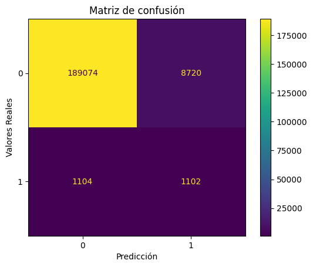

```
CPU times: total: 45.4 s
Wall time: 3min 28s
```

```python
%%time

columnas_eliminar_11 = [
    'device_fraud_count',
    'email_is_free',
    'phone_mobile_valid',
    'velocity_6h',
    'income',
    'proposed_credit_limit'
]

hiperparametros_11, train_11, test_11 = procesar_datos_y_modelo(pd_fraude_train, pd_fraude_test, columnas_eliminar_11)
```

# Conclusión

Después de haber probado diversas combinaciones de variables, los mejores resultados los hemos obtenido eliminando las varibales 'device_fraud_count', 'phone_mobile_valid', 'velocity_6h' y 'source', con un F2-score de 0.303. En nuestra opinión, son los resultados que mejor se ajustan a lo que entendemos como solución del problema, maximizar todo lo que se pueda los Verdaderos Positivos, mientras se intentan minimizar los Falsos Positivos y Falsos Negativos (dándole mayor importancia a los Falsos Negativos).

Los hiperparámetros que ha determinado la búsqueda son: {'subsample': 0.8, 'num_leaves': 3, 'n_estimators': 500, 'min_child_samples': 30, 'max_depth': 7, 'learning_rate': 0.5, 'colsample_bytree': 1.0}

```python
train_4.to_csv('./data/pd_train_best_param.csv')
test_4.to_csv('./data/pd_test_best_param.csv')
```